# Модель стационарного временного ряда ARMA

© Alexander Doynikov,dep. CS, MSU

Aвгуст 11, 2021

# Модели стационарных временных рядов

В этой лекции через $y_t$ будет обозначать наблюдаемый случайный процесс, а $\epsilon_t$ ненаблюдаемый процесс белого шума. Общим линейным процессом типа скользящего среднего называется процесс вида
$$y_t=\epsilon_t+\psi_1\epsilon_{t-1}+\psi_2\epsilon_{t-2}+....+\psi_n\epsilon_{t-n}+....$$
Введем линейный оператор сдвига назад $B: By_t=y_{t-1}$

По индукции $B^k: B^ky_t=y_{t-k}$

Используя оператор сдвига, определение линейного процесса типа скользящего среднего будем записывать в операторном виде $y_t=(1+\psi_1B+\psi_2B^2+.....)\epsilon_t= \psi(B)\epsilon_t$

Будем предполагать, что

$\sum_{i=1}^{\infty}\psi_i < \infty$

Важный нетривиальный пример такого процесса это процесс, где все $\psi_i=\phi^i$, при $-1<\phi<1$

В этом случае

$$y_t= (1+\phi B+\phi^2B^2+...)\epsilon_t=\epsilon_t+\phi\epsilon_{t-1}+\phi^2\epsilon_{t-2}+...$$

Так как $\epsilon_t$ - процесс белого шума $E[\epsilon_t]=0$, поэтому

$E[y_t]=E[\epsilon_t+\phi\epsilon_{t-1}+\phi^2\epsilon_{t-2}+...]= 0$

Пусть $D[\epsilon_t]=\sigma_{\epsilon}^2$ тогда

$D[y_t]=D[\epsilon_t+\phi\epsilon_{t-1}+\phi^2\epsilon_{t-2}+...]= \sigma_{\epsilon}^2+\phi^2\sigma_{\epsilon}^2+\phi^4\sigma_{\epsilon}^2+... = \sigma_{\epsilon}^2(1+\phi^2+\phi^4+...)= \frac{\sigma_{\epsilon}^2}{1-\phi^2}$

Вычислим автоковариационную и автокорреляционную функции процесса

$c_1=cov(y_t,y_{t-1})= cov((\epsilon_t+\phi\epsilon_{t-1}+\phi^2\epsilon_{t-2}+...),( \epsilon_{t-1}+\phi\epsilon_{t-2}+\phi^2\epsilon_{t-3}+...))= \phi\sigma_{\epsilon}^2(1+\phi^2+\phi^4+...)=\frac{\phi\sigma_{\epsilon}^2}{1-\phi^2}$

$corr(y_t,y_{t-1})= \frac{\phi\sigma_{\epsilon}^2}{1-\phi^2}/(\frac{\sigma_{\epsilon}^2}{1-\phi^2})= \phi$

Аналогично вычислим

$c_k=cov(y_t,y_{t-k})=\frac{\phi^k\sigma_{\epsilon}^2}{1-\phi^2}$

$\gamma_k=corr(y_t,y_{t-k})=\phi^k$

Для произвольного линейного процесса скользящего среднего $y_t=(1+\psi_1B+\psi_2B^2+.....)\epsilon_t= \psi(B)\epsilon_t$ Нетрудно вычислить, что

$E[y_t=0]$,

$c_k=cov(y_t,y_{t-k})=\sigma_{\epsilon}^2\sum_{i=0}^{\infty}\psi_i\psi_{i+k}$

Важно отметить, что ковариационная функция не зависит от $t$ , зависит только от задержки $k$ cледовательно это стационарный процесс с нулевым среднем. Для получения процесса с произвольным среднем $\mu$ просто добавим $\mu$ к правой части соотношения $y_t=(1+\psi_1B+\psi_2B^2+.....)\epsilon_t+\mu= \psi(B)\epsilon_t+\mu$

В случае конечного числа $\psi_k$ отличных от нуля модель записывают в виде

$y_t=\mu+\epsilon_t-\theta_1\epsilon_1- ...-\theta_q\epsilon_q$

называют моделью скользящего среднего порядка $q$ и обозначают $MA(q)$

## Модель $MA(1)$

Подробно рассмотрим модель скользящего среднего первого порядка с нулевым среднем $y_t=\epsilon_t-\theta\epsilon_{t-1}$

Cогласно проведенным выше вычислениям сразу запишем, что автоковариационная функция процесса $y_t$

$c_0=D[y_t]= \sigma_{\epsilon}^2(1+\theta^2)$

$c_1=cov(y_t,y_{t-1})=-\sigma_{\epsilon}^2\theta$

$c_k = 0$ при $|k|>1$

автокорреляционная функция процесса $y_t$

$\rho_0=1$

$\rho_1= -\theta/(1+\theta^2)$

$\rho_k= 0$ при $|k|>1$

Поведение процесса, выборочной и модельной (True ACF) автокорреляционной функции при различных параметрах $\theta$ можно изучить в прилагаемом ниже фрейме. Понятие частной автокорреляционной функции (PACF) и спектра в курсе дано будет позднее https://shiny.ilykei.com/ANDoynikov/ARMA_Model/MA(1)_Model/

Пример моделирования $MA(1)$ на R при $\theta=0.9$

```r
library(TSA)
```

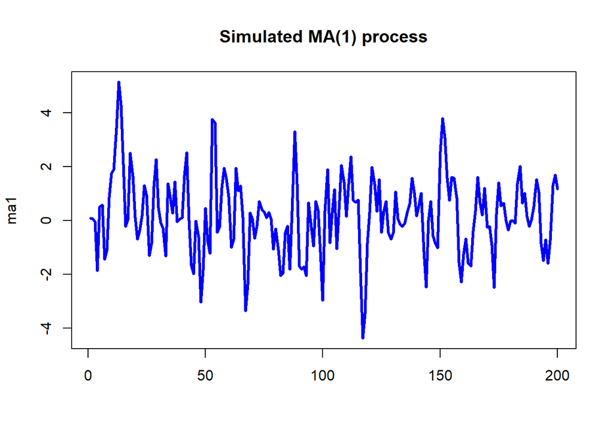

```r
library(astsa)
library(graphics)
library(plotrix)
theta <- 0.9
modelMA <- list(ma= theta)
ma1<-arima.sim(modelMA,n=200)
matplot(ma1,main= "Simulated MA(1) process",type = "l",lwd=3,col="blue")
```

Для того чтобы визуально увидеть зависимость ряда от прошлого полезно строить график $y_t$ от $y_{t-1}$ и увидеть положительную корреляцию между ними

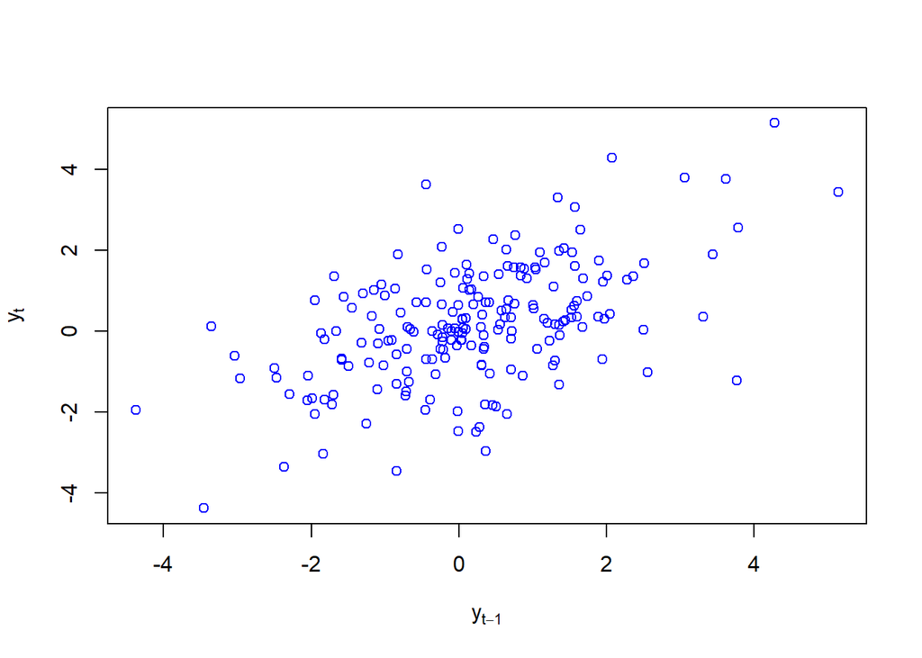

```r
plot(ma1,zlag(ma1), ylab = expression(y[t]),xlab = expression(y[t-1]),type='p',col = 'blue')
```

Корреляции между $y_t$ от $y_{t-2}$ уже не будет.

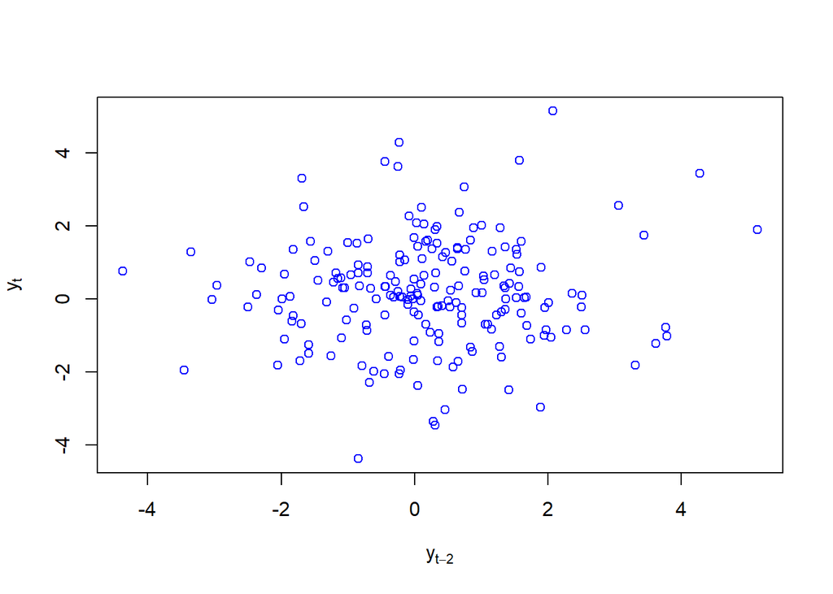

```r
plot(ma1,zlag(ma1,2), ylab = expression(y[t]),xlab = expression(y[t-2]),type='p',col = 'blue')
```

## Процесс $MA(q)$

Теперь рассмотрим процесс скользящего среднего произвольного порядка $MA(q)$

$y_t=\epsilon_t-\theta_1\epsilon_{t-1}-...-\theta_q\epsilon_{t-q}$

Для процесса $y_t$ дисперсия

$c_0=D[y_t]=\sigma_{\epsilon}^2(1+\theta_1^2+....+\theta_q^2)$

автокорреляционная функция

$\rho_k= \frac{-\theta_{k}+\theta_{k-1}\theta_{1}-\theta_{k-2}\theta_{2}+\theta_{k-q}\theta_{q}}{(1+\theta_1^2+....+\theta_q^2)}$ при $k=1,...,q$

$\rho_k=0$ при $k>q$

Поведение процесса, выборочной и модельной (True ACF) автокорреляционной функции при различных параметрах $\theta_1,\theta_2,\theta_3,$ можно изучить в прилагаемом ниже фрейме на примере процесса $MA(3)$. https://shiny.ilykei.com/ANDoynikov/ARMA_Model/MA(3)_Model

## Процессы авторегрессии

Общим линейным процессом типа авторегрессии называется процесс вида
$$y_t=\epsilon_t+\pi_1y_{t-1}+\pi_2y_{t-2}+....+\pi_ny_{t-n}+....$$
или в операторном виде
$$\pi(B)y_t=\epsilon_t$$

Название происходит от регрессии самого на себя. Процесс вида

$y_t= \phi_1y_{t-1}+\phi_2y_{t-2}+...+\phi_py_{t-p}+\epsilon_t$

назвается процессом авторегрессии порядка $p$ обозначается $AR(p)$. Запись с использованием оператора сдига назад $B$ и в операторной форме

$(1 - \phi_1B-\phi_2B^2-...- \phi_pB^p) y_t=\phi(B)y_t=\epsilon_t$

## Соотношение между $\pi(B)$ и $\psi(B)$

Итак мы имеем два типа предствления
$$\pi(B)x_{t}=\epsilon_{t}$$
и
$$x_{t}=\psi(B)\epsilon_{t}$$

Умножим первое из них слева на $\psi(B)$
$$\psi(B)\pi(B)x_{t}=\psi(B)\epsilon_{t}=x_{t}$$
Отсюда следует, что
$$\psi(B)\pi(B)=1$$
или
$$\psi(B)=\pi^{-1}(B)$$

## Процесс авторегрессии 1 порядка $AR(1)$

Пусть стационарный процесс c нулевым среднем представим в виде

$y_t=\phi y_{t-1}+\epsilon_t$

или, используя оператор сдвига

$\phi(B)x_t = \epsilon_t$

где $\phi(B)=1-\phi B$

Вычислим дисперсию $c_0=D[y_t]$

$c_0=\phi^2c_0+\sigma_{\epsilon}^2$

Умножая выражение для процесса на $y_{t-k}$ и ,беря математическое ожидание от обеих частей получим выражение для ACF процесса

$E[y_ty_{t-k}]= \phi E[y_{t-1}y_{t-k}]+E[\epsilon_ty_{t-k}]$

$c_k= \phi c_{k-1}$

Откуда

$c_k=\phi^k \frac{\sigma_{\epsilon}^2}{1-\phi^2}$

Автокорреляционная функция

$\rho_k=\frac{c_k}{c_0}=\phi^k$

Предположим, чьл $|\phi |< 1$ в этом случае $\rho_k->0$ при $k->\infty$

Поведение процесса, выборочной и модельной (True ACF) автокорреляционной функции при различных параметрах $\phi$ можно изучить в прилагаемом ниже фрейме на примере процесса $AR(1)$. https://shiny.ilykei.com/ANDoynikov/ARMA_Model/AR(1)_Model

Пример моделирования $AR(1)$ на R при $\phi=0.9$

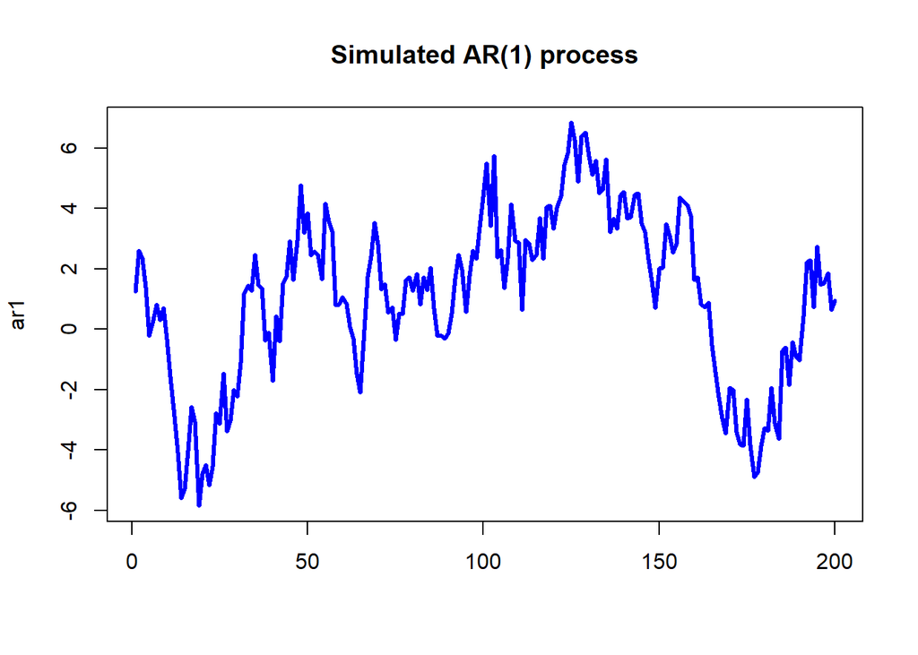

```r
phi <- 0.9
model <- list(ar= phi)
ar1<-arima.sim(model,n=200)
matplot(ar1,main= "Simulated AR(1) process",type = "l",lwd=3,col="blue")
```

Процесс $AR(1)$ стационарен тогда и только тогда, $|\phi|<1$, что эквиваленетно тому, что корень уравнения $\phi(B) = 0$ по модулю больше 1.

Для того чтобы визуально увидеть зависимость ряда от прошлого полезно строить график $y_t$ от $y_{t-1}$ и увидеть положительную корреляцию между ними

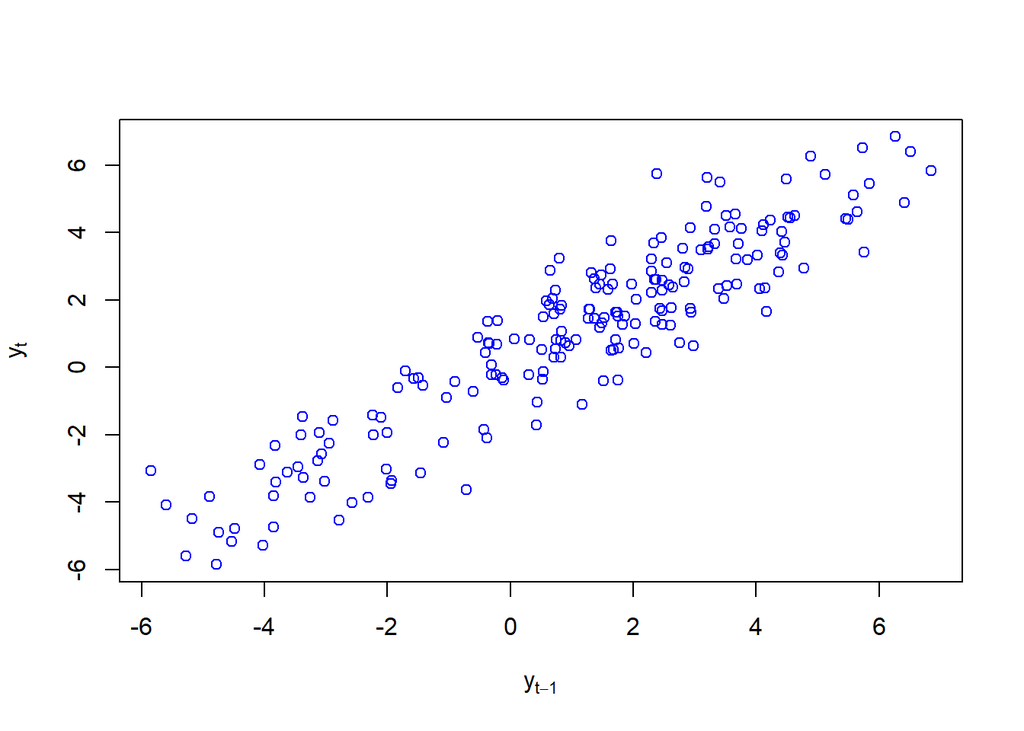

```r
plot(ar1,zlag(ar1), ylab = expression(y[t]),xlab = expression(y[t-1]),type='p',col = 'blue')
```

Остается корреляция между $y_t$ от $y_{t-2}$

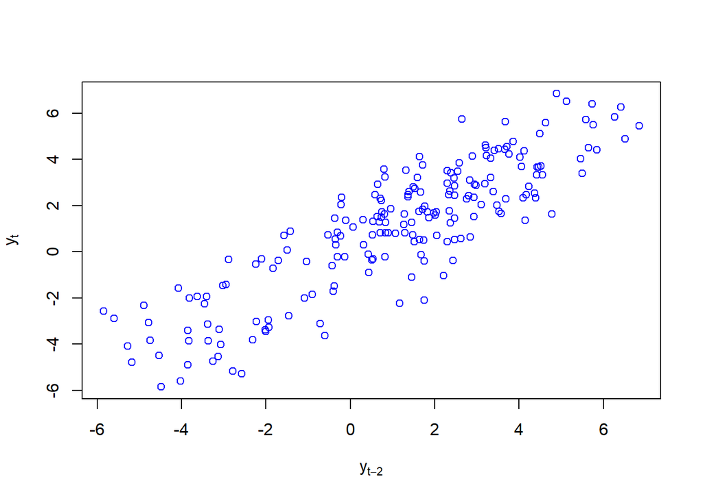

```r
plot(ar1,zlag(ar1,2), ylab = expression(y[t]),xlab = expression(y[t-2]),type='p',col = 'blue')
```

## Процесс авторегрессии 2 порядка. $AR(2)$

Пусть процесс c нулевым среднем представим в виде

$y_t=\phi_1 y_{t-1}+\phi_2 y_{t-2}+ \epsilon_t$

или, используя оператор сдвига

$\phi (B)x_t = \epsilon_t$

где $\phi(B)=1-\phi_1 B- \phi_2 B^2$

Можно покачать, что для стационарности $AR(2)$ процесса необходимо и достаточно, чтобы корни характеристического уравнения $\phi(B) = 0$ или $1-\phi_1 B- \phi_2 B^2=0$ по модулю были больше 1. Корни характеристического уравнения легко найти

$B_{1,2}=\frac{\phi_1+-\sqrt{\phi_1^2+4\phi_2}}{-2\phi_2}$

Абсолютные значения корней должны быть больше 1. Отсюда можно получить условия на $\phi_1,\phi_2$ а именно

$\phi_1+\phi_2<1$,$\phi_2-\phi_1<1$ и $|\phi_2|<1$

Вычислим автоковариационную и автокорреляционную функции процесса $AR(2)$ Умножая предствление процесса на $y_{t-k}$ и, беря математическое ожидание, получим

$c_k= \phi_1c_{k-1}+\phi_2c_{k-2}$ $:k=1,2,....$

автокорреляционная функция

$\rho_k= \phi_1\rho_{k-1}+\phi_2\rho_{k-2}$ $:k=1,2,....$

Последнее уравнение носит название уравнение Юла-Уокера. Его обычно решают численно, но существует и другой способ нахождения $\rho_k$ обозначим через $G_1,G_2$ корни характеристического уравнения $1-\phi_1 B- \phi_2 B^2=0$

$G_1= \frac{\phi_1+\sqrt{\phi_1^2+4\phi_2}}{2}$

$G_2= \frac{\phi_1-\sqrt{\phi_1^2+4\phi_2}}{2}$

Если $G_1\ne G_2$ то можно показать,что

$\rho_k=\frac{(1-G_2^2)G_1^{k+1}- (1-G_1^2)G_2^{k+1}}{(G_1-G_2)(1+G_1G_2)}$

Eсли корни комплексны, тогда

$\rho_k=R^k\frac{sin(\Theta k+\Phi)}{sin\Phi}$

где $R =\sqrt{-\phi_2}$, $cos\Theta=\phi_1/(2\sqrt{-\phi_2})$ и $tan\Phi=(1-\phi_2)/(1+\phi_2)$

Поведение процесса, выборочной и модельной (True ACF) автокорреляционной функции при различных параметрах $\phi_1,\phi_2$ можно изучить в прилагаемом ниже фрейме на примере процесса $AR(2)$. https://shiny.ilykei.com/ANDoynikov/ARMA_Model/AR%282%29%20Model/

Пример моделирования $AR(2)$ на R при $\phi_1=0.4,\phi_2=-0.5$

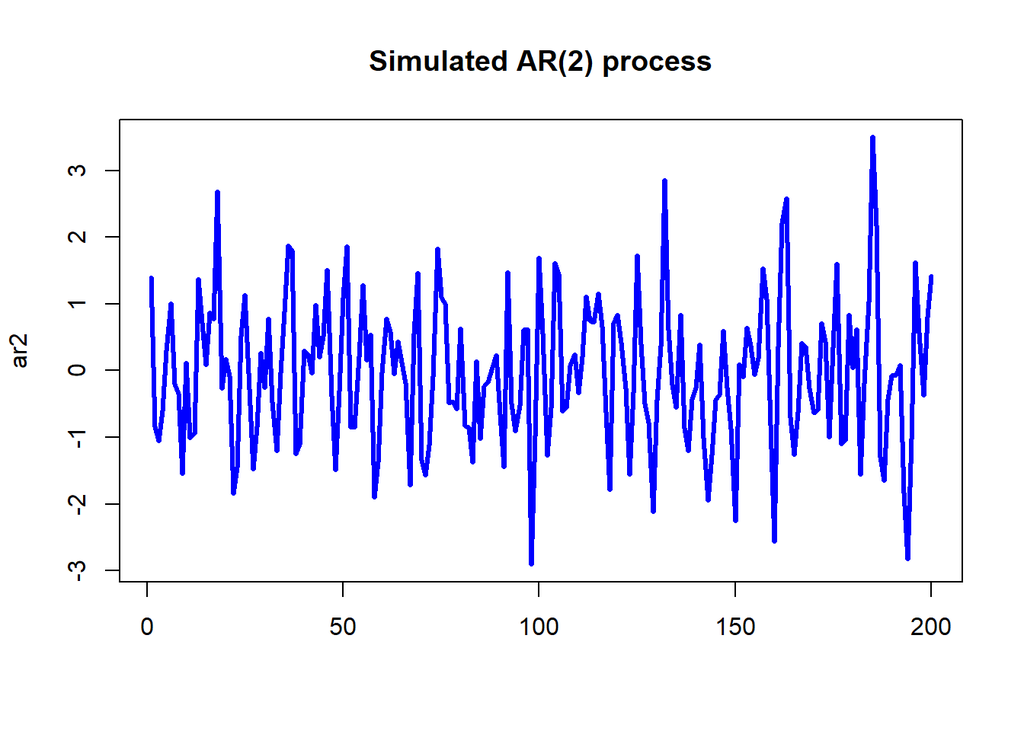

```r
phi <- c(0.4,-0.5)
model <- list(ar= phi)
ar2<-arima.sim(model,n=200)
matplot(ar2,main= "Simulated AR(2) process",type = "l",lwd=3,col="blue")
```

### Дисперсия процесса $AR(2)$

Чтобы вычислить дисперсию процесса $AR(2)$ возьмем оператор дисперсии от обеих частей $y_t=\phi_1 y_{t-1}+\phi_2 y_{t-2}+ \epsilon_t$

$c_0=D[y_t]=(\phi_1^2+\phi_2^2)+2\phi_1\phi2+\sigma_{\epsilon}^2$ $(*)$

У нас есть уравнение $c_k= \phi_1c_{k-1}+\phi_2c_{k-2}$ $:k=1,2,....$ при $k=1$ оно примет вид $c_1= \phi_1c_{0}+\phi_2c_{1}$ Уравненике $(*)$ и последнее уравнение нам даст

$c_0=\frac{1-\phi_1}{1+\phi_2}\frac{\sigma_{\epsilon}^2}{(1-\phi_2)^2-\phi_1^2}$

## Процесс авторегрессии произвольного порядка. $AR(p)$

Процесс вида

$y_t=\phi_1 y_{t-1}+\phi_2 y_{t-2}+...-+\phi_p y_{t-p}+ \epsilon_t$ $(1)$

называется процессом авторегрессии порядка $p$

В операторной форме

$\phi (B)y_t = \epsilon_t$

$(1-\phi_1 B-...-\phi_p B^p)y_t = \epsilon_t$

характеристическое уравнение

$1-\phi_1 B-...-\phi_p B^p= 0$

Процесс авторегрессии порядка $p$ стационарен тогда и только тогда корни характеристического уравнения по модулю больше единицы, или корни лежат вне единичной окружности $|z|= 1$

Пример

$\phi_1=0.6,\phi_2=-0.3,\phi_3= 0.2$

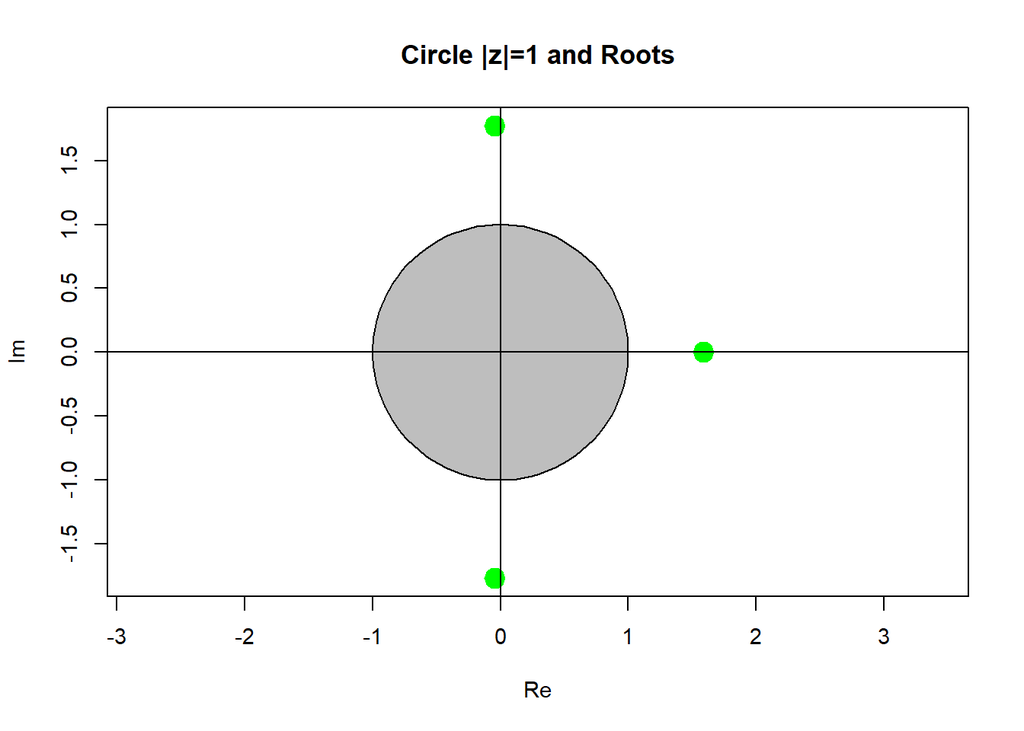

```r
library(plotrix)

ARMARoots <-function (ar,col)
{
  p <- c(1,-ar)
  r=polyroot(p) # solve the polynomial equation
  rRe<-Re(r)
  rIm<-Im(r)
  plot(rRe,rIm,asp=1,lwd = 8,xlab="Re",ylab="Im",main = "Circle |z|=1 and Roots",pch = 20,col = col,xlim=c(min(rRe,-1),max(rRe,1)),ylim=c(min(rIm,-1),max(rIm,1)))
  draw.circle(0,0,radius=1,border="black",col = "grey")
  points(rRe,rIm,lwd=8,col= col)
  abline(v=0)
  abline(h=0)
}

phi1<-0.6
phi2<--0.3
phi3 <- 0.2
par(mfrow = c(1, 1), cex = 0.9)
ARMARoots(c(phi1,phi2,phi3),"green")
```

Умножая (1) на $y_{t-k}$, и ,разделив на $c_0=D[y_t]$, берем математическое ожидание от обоих частей полученного соотношения, получим

$\rho_k=\phi_1\rho_{k-1}+...+\phi_p \rho_{k-p}$

Полагая последовательно $k=1,..,p$, получим систему линейных алгебраических уравнений

$\rho_1=\phi_1+...+\phi_p \rho_{p-1}$

$\rho_2=\phi_1\rho_1+...+\phi_p \rho_{p-2}$

$...$

$\rho_p=\phi_1\rho_{p-1}+...+\phi_p$

Эта система уравнений носит название Юла-Уокера. Зная набор чисел $\phi_1,\phi_2,...,\phi_p$ можно из системы вычислить $\rho_1,\rho_2,...,\rho_p$ и наоборот.

С уравнением Юла Уокера связано появление функции частной автокорреляции (PACF). Последовательно будем решать их для $k=1,2,...,p$ При $k=1$ оно имет вид
$$\rho_1=\phi_1$$
Решение его обозначим $\phi_{1,1}$.

Для $k=2$
$$\rho_1=\phi_1+\phi_2\rho_{1}$$

$$\rho_2=\phi_1\rho_1+\phi_2$$
Решение его обозначим $\phi_{2,1},\phi_{2,2}$. И так далее повышаем порядок уравнения и решения для порядка $k$ его обозначаем $\phi_{k,1},\phi_{k,2},..., \phi_{k,k}$. Функция от $k$, поученная из решений уравнения при старших степенях уравнений
$$\phi_{1,1},\phi_{2,2},...,\phi_{p,p},...,\phi_{k,k}$$
получила название частной автокорреляционной функции (PACF). Для $AR(p)$ она по построению имеет отличные от нуля значения до
$$\phi_{1,1},\phi_{2,2},...,\phi_{p,p}$$
далее при $k>p$ должны следовать нули так как соответствующие $\phi_k$ в модели $AR(p)$ имеются в наличии только до порядка $p$. На практике конечно нули мы не увидим однако, дисперсия
$$D[\phi_{k,k}]\approx\frac{1}{n}$$
попадание значений PACF в полосу $\pm\frac{1}{\sqrt{n}}$ является сигналом к идентификации порядка модели $p$.

Выражение для дисперсии процесса получим из (1), умножив его на $y_t$, и , беря математическое ожидание, получим

$D[y_t]= c_0= \frac{\sigma_{\epsilon}^2}{1-\phi_1\rho_1-... -\phi_p\rho_p}$

Поведение процесса, выборочной и модельной (True ACF,PACF) автокорреляционной функции и частной автокорреляционной при различных параметрах $\phi_1,\phi_2,\phi_3$ можно изучить в прилагаемом ниже фрейме на примере процесса $AR(3)$. https://shiny.ilykei.com/ANDoynikov/ARMA_Model/AR(3)_Model/

## Идентификация моделей $AR(p)$ и $МА(q)$

PACF и ACF служат прекрасным средством для идентификации модели и их порядков на практике. Сведем наши знания об этих функциях в следующую таблицу

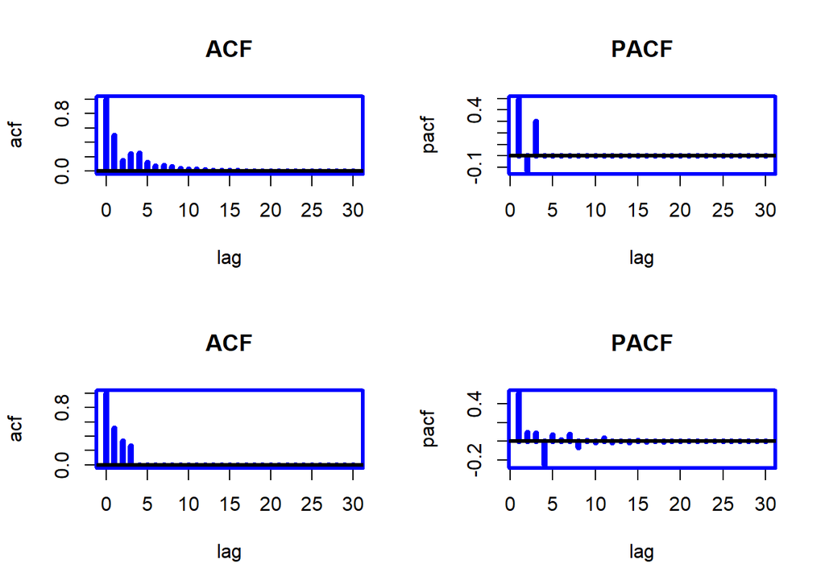

```r
  par(mfrow = c(2, 2), cex = 1.0,col = "blue",lwd = 3)
  phi1 = 0.6
  phi2 = -0.3
  phi3 = 0.3
  modelAR3 <- list(ar=c(phi1,phi2,phi3))
  acf <- ARMAacf(ar=c(phi1,phi2,phi3),lag.max = 30,pacf = FALSE)
  pacf <- ARMAacf(ar=c(phi1,phi2,phi3),lag.max = 30,pacf = TRUE)
  m <- length(acf)
  matplot(0:(m-1),acf,type= 'h',main = 'ACF',col = 'blue',lwd = 5,xlab = 'lag',ylab='acf')
 abline(h = 0,untf = TRUE,col = 'black')
  matplot(pacf,type= 'h',main = 'PACF',col = 'blue',lwd = 5,xlab = 'lag',ylab='pacf')
        abline(h = 0,untf = TRUE,col = 'black')
  theta1 = 0.5
  theta2 = 0.3
  theta3 = 0.4
  modelMA3 <- list(ma=c(theta1,theta2,theta3))
  acf <- ARMAacf(ma=c(theta1,theta2,theta3),lag.max = 30,pacf = FALSE)
  pacf <- ARMAacf(ma=c(theta1,theta2,theta3),lag.max = 30,pacf = TRUE)
  m <- length(acf)
  matplot(0:(m-1),acf,type= 'h',main = 'ACF',col = 'blue',lwd = 5,xlab = 'lag',ylab='acf')
 abline(h = 0,untf = TRUE,col = 'black')
  matplot(pacf,type= 'h',main = 'PACF',col = 'blue',lwd = 5,xlab = 'lag',ylab='pacf')
        abline(h = 0,untf = TRUE,col = 'black')
```

# Смешаный процесс $ARMA(p,q)$

Процесс с нулевым среднем вида

$y_t= \phi_1y_{t-1}+ ...+ \phi_py_{t-p}+\epsilon_t- \theta_1\epsilon_{t-1}-..-\theta_q \epsilon_{t-q}$

называется cмешаным процессом авторегрессии-скользящего среднего порядка $p,q$, обозначается $ARMA(p,q)$ В операторной записи

$(1-\phi_1B-...-\phi_pB^P)y_t= (1-\theta_1B-...-\theta_pB^q)\epsilon_t$

$\phi_p(B)y_t= \theta_q(B)\epsilon_t$

### $ARMA(1,1)$ модель

Начнем с простейшей модели ARMA(1,1).

$y_t= \phi_1y_{t-1}+\epsilon_t- \theta_1\epsilon_{t-1} (2)$

Так как

$E\epsilon_t y_t= E[\epsilon_t\phi_1y_{t-1}]+E[\epsilon_t\epsilon_t]- E[\theta_1\epsilon_t\epsilon_{t-1}]= \sigma_{\epsilon}^2$

$E\epsilon_{t-1} y_t= E[\epsilon_{t-1}\phi_1y_{t-1}]+E[\epsilon_{t-1}\epsilon_t]- E[\theta_1\epsilon_{t-1}\epsilon_{t-1}]= \phi_1\sigma_{\epsilon}^2-\theta_1\sigma_{\epsilon}^2= \sigma_{\epsilon}^2(\phi_1-\theta_1)$

Если умножить на $y_{t-k}$ и взять математическое ожидание , то прдем к следуюшей системе соотношений
$$c_0=\phi_1c_1+[1-\theta_1(\phi_1-\theta_1)]\sigma_{\epsilon}^2$$
$$c_1= \phi_1c_0-\theta_1\sigma_{\epsilon}^2$$
$$c_k= \phi_1c_{k-1}$$

Разрешая это систему получим, что
$$\rho_k= \frac{(1-\theta_1\phi_1)(\phi_1-\theta_1)}{1-2\theta_1\phi_1-\theta_1^2}/phi_1^k$$
для $k>0$.

Таким образом ACF убывает с ростом $k$ также как и модель $AR(1)$

## $ARMA(p,q)$ модель

Запишем модель в операторном виде.
$$\phi_p(B)y_t=\theta_q(B)\epsilon_t$$
Без доказательства (громоздкие формулы) примем следующий факт, что в ACF первый $q$ значений ведут себя произвольно,а начиная с задержки $q+1$ идет экспоненциальное затухание аналогичное модели AR(p).

Стационарность модели зависит от характеристического многочлена $\phi_p(B)=0$ в том смысле,что корни его должны лежать вне единичного круга $|B| = 1|$.

Обратимость определяется многочленом $\theta_q(B)=0$.Корни его соответственно должны лежать вне единичного круга $|B| = 1|$.

### Идентификация $ARMA(p,q)$ моделей. EACF(Extended ACF)

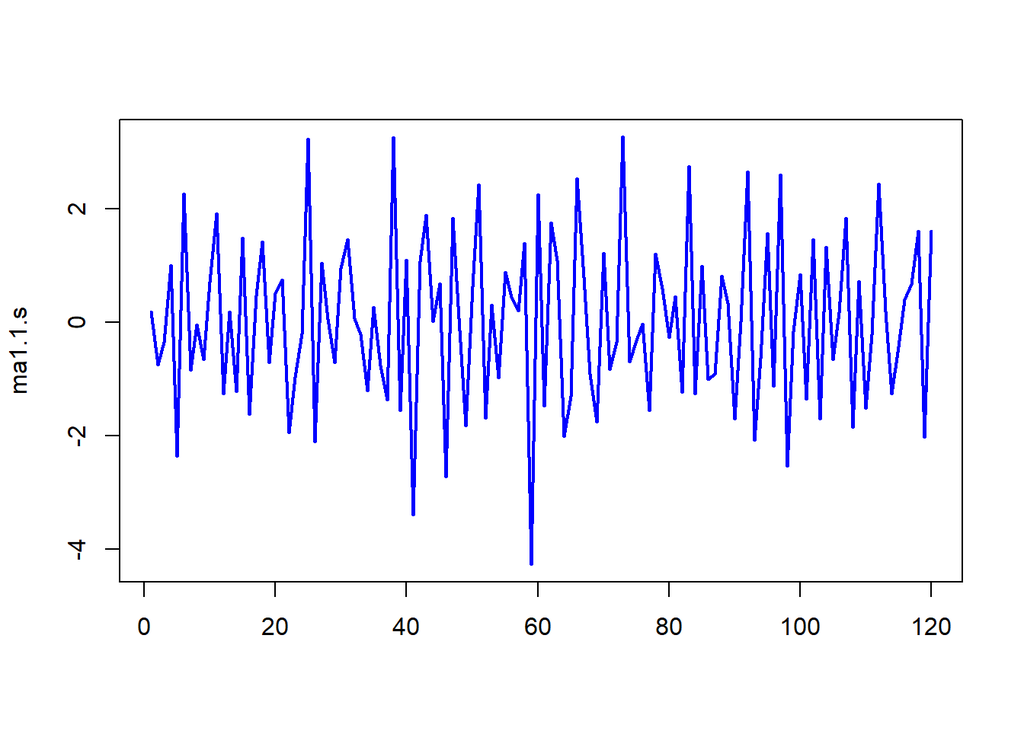

```r
  library(TSA)
  data("ma1.1.s")
  matplot(ma1.1.s, lwd = 2,col = "blue",type ="l")
```

Его ACF и PACF выглядят так

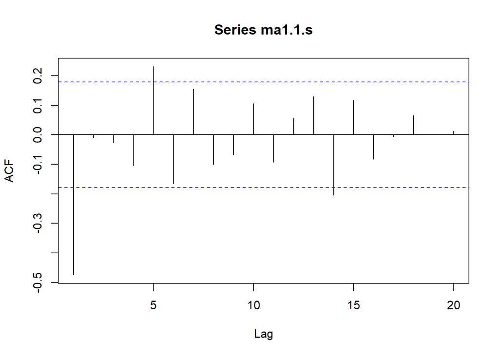

```r
  acf(ma1.1.s)
```

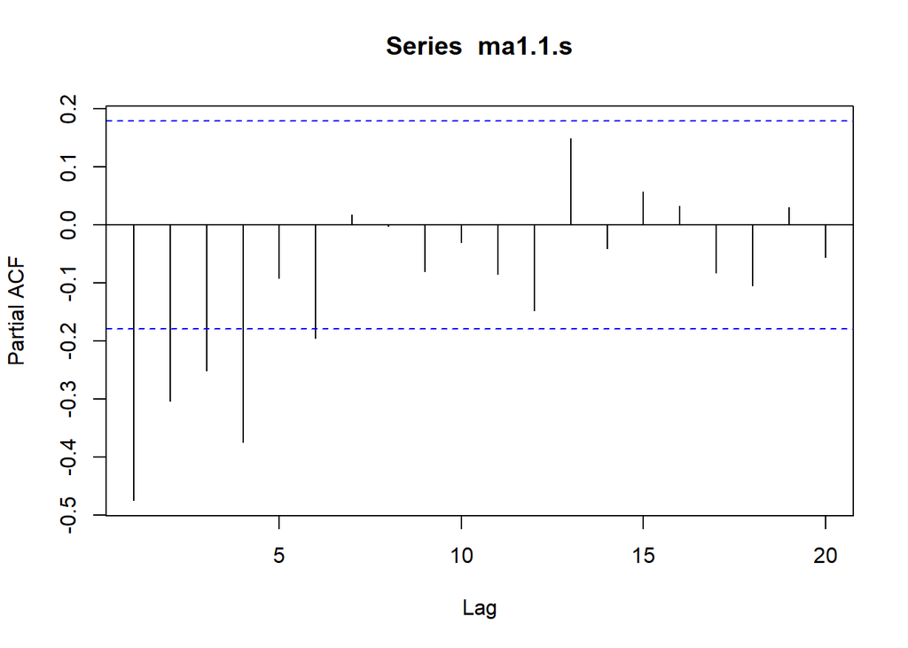

```r
  pacf(ma1.1.s)
```

```r
  eacf(ma1.1.s)
```

```
## AR/MA
##   0 1 2 3 4 5 6 7 8 9 10 11 12 13
## 0 x o o o x o o o o o o  o  o  x
## 1 x o o o o o o o o o o  o  o  o
## 2 x o o o o o o o o o o  o  o  o
## 3 x x x x o o o o o o o  o  o  o
## 4 x x o x x o o o o o o  o  o  o
## 5 x x o o x x o o o o o  o  o  o
## 6 o o x x x x o o o o o  o  o  o
## 7 o o x o o x o o o o o  o  o  o
```

Для практического ознакомления со смешаными моделями предлагаю следующий фрейм. https://shiny.ilykei.com/ANDoynikov/ARMA_Model/ARMA(3,3)

# Задача для теста

Попробуйте решить задачу идентификации модели в следующем фрейме

Моделируется модель либо $AR(p)$
$$x_t=\phi_1x_{t-1}+\phi_2x_{t-2}+...+\phi_px_{t-p}+\epsilon_t,$$
либо MA(q) модель
$$x_t=\epsilon_t+\theta_1\epsilon_{t-1}+\theta_2\epsilon_{t-2}+...+\theta_q\epsilon_{t-q}$$
$p,q \le 4$.

Выдается сам ряд, и выборочные ACF и PACF. Всего вариантов моделирования 10. За правильнную идентификацию типа модели AR или МA получаете 0.5 балла.За правильную идентификацию порядка модели также получаете 0.5 балла. Итого за полностью правильно идентифицированную модель можно заработать 1 балл. Положительным результатом теста считается 7 набранных баллов за все 10 вариантов.

Переход к следующему варианту осуществляется нажатием кнопки “Next Option”"

Варианты возникают в случайном порядке. Результат теста выдается после выполнения всех 10 вариантов. После чего тест можно продолжить для следующих 10 случайно выбранных вариантов.

#### Указание

Для того, чтобы выборочные ACF,PACF выглядели более характерно рекомендуется изменить длительность ряда. https://shiny.ilykei.com/ANDoynikov/ARMA_Model/Identification_ARMA_test